# Nav1.2_Fenestration_Analyses

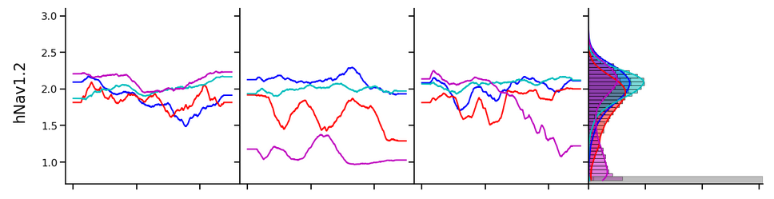

Unlike other Nav subtypes where DI-IV is consistently closed, we observe errant behaviour in the DI-IV bottleneck radius of Nav1.2 across the three replicates. Replicate 1 has converged on a state where DI-IV is potentially the most open out of all four fenestrations; whereas the closed state is observed in Replicate 2; and interestingly, Replicate 3 captures the transition from open to closed.

## Bottleneck residues for each fenestration

Over 60 residues returned by Caver; only plotting the *top bottleneck residues* identified in >2000 (out of 5000) frames in all of the three repeats; coloured according to fenestration- DI-II (blue), DII-III (red), DIII-IV (green), DI-IV (magenta)

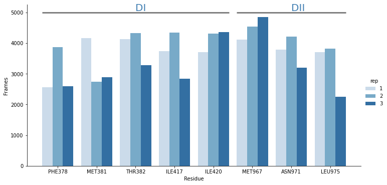

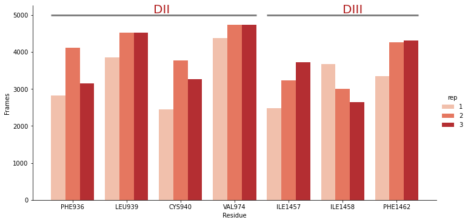

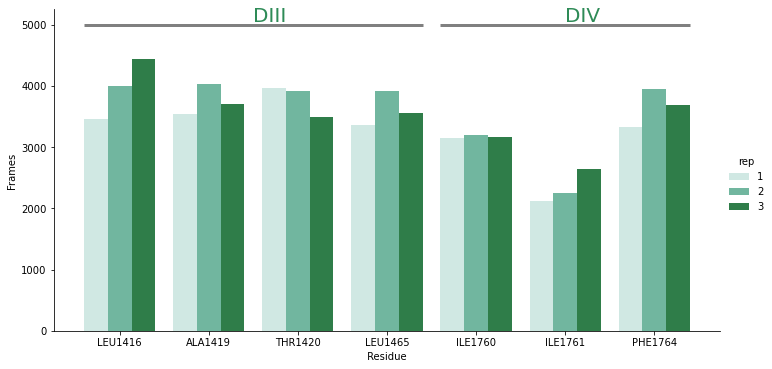

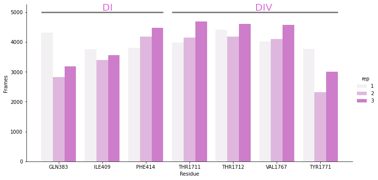

## Deleting side chains from bottleneck residues

In the case of opening up the closed fenestration states, removing aromatic side chains of S6 has an effect, however, not as pronounced as in other Nav subtypes (could be some other structural change in the pore helices dictating fenestration radii in Nav1.2 that is more significant than the BR side chains). Potential mutations:

- PHE414ALA to open DI-IV
- THR1711ALA (near the selectivity filter) could also open up DI-IV
- PHE1462ALA to widen DII-III

### REP2 (DI-IV)

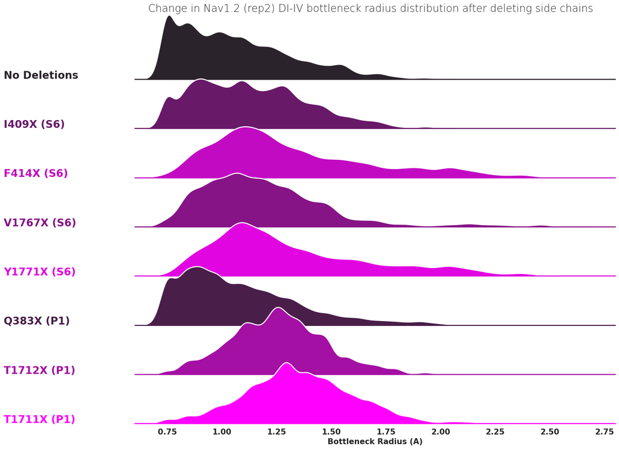

### REP3 (DI-IV)

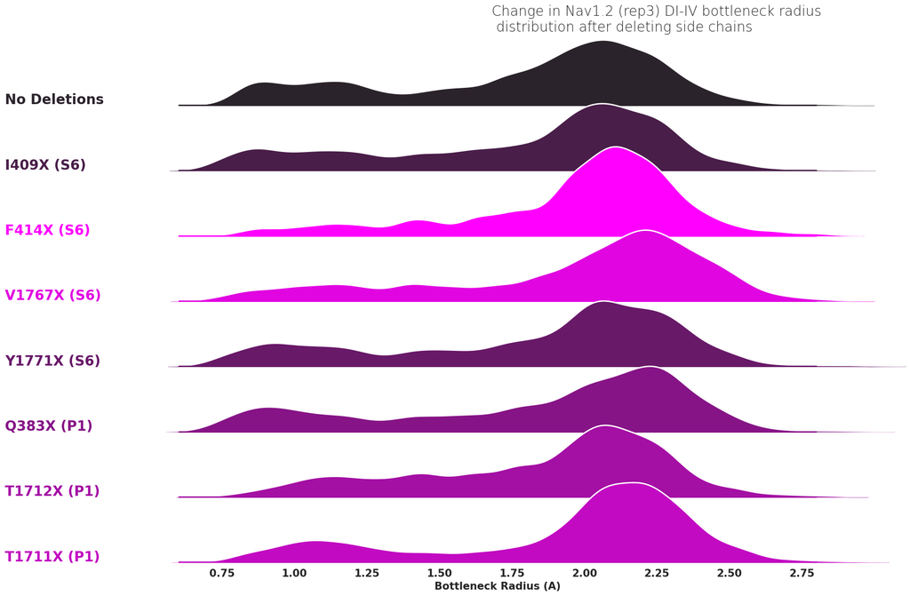

### REP2 (DII-III)

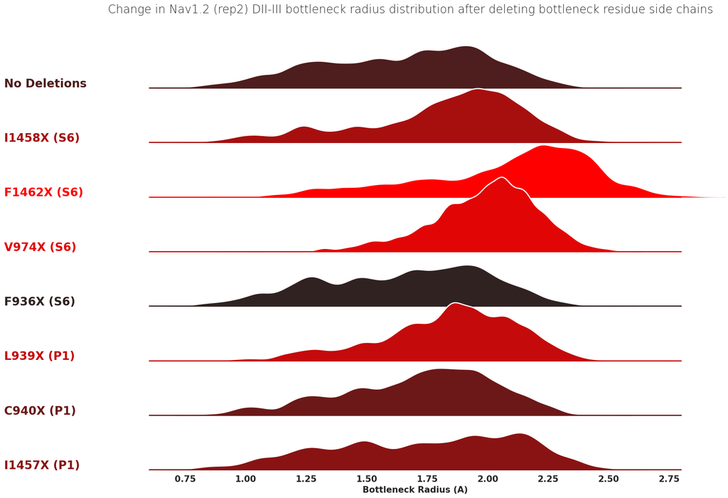

### REP3 (DII-III)

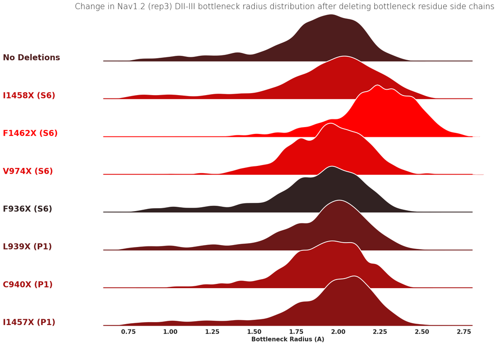